# Analysis of the Difference in Means of Systolic Blood Pressure between Smokers and Non-Smokers

Brock Akerman and Hanan Ali

ST502 - Spring 2022

## **The t-Test**

A sample of data is extracted from the Framingham Heart Study which includes the systolic blood pressure of participants who are identified as either smokers or non-smokers. Smokers in this study are defined as participants who have smoked cigarettes anytime during the year preceding the physical examination while non-smokers are those who have abstained from smoking during that same period of time (Magnani, 2017). The data contains a column of qualitative binary values characterizing the subjects’ smoking habit and a second column pairing it with a single measurement of systolic blood pressure measured in millimeters of mercury (mmHg).

We are interested in making inference about the difference in blood pressure means between smokers and non-smokers. To test whether a difference between means exists, we will utilize the pooled t-test and the Welch-Satterthwaite t-test. Random sampling and a normal distribution are assumed for our samples; however, examining plots of the data before conducting any t-tests regardless of assumptions made is good habit. If assumptions about samples are made and there is any opportunity to strengthen the results of our test by reinforcing those assumptions, then we should do so.

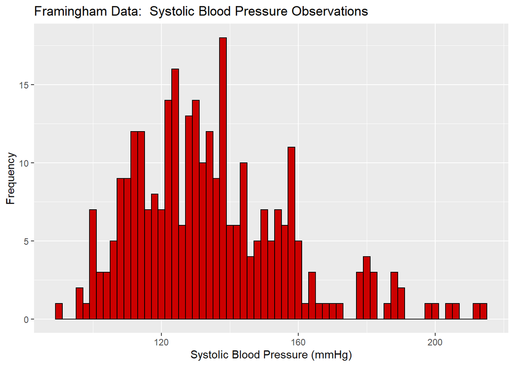

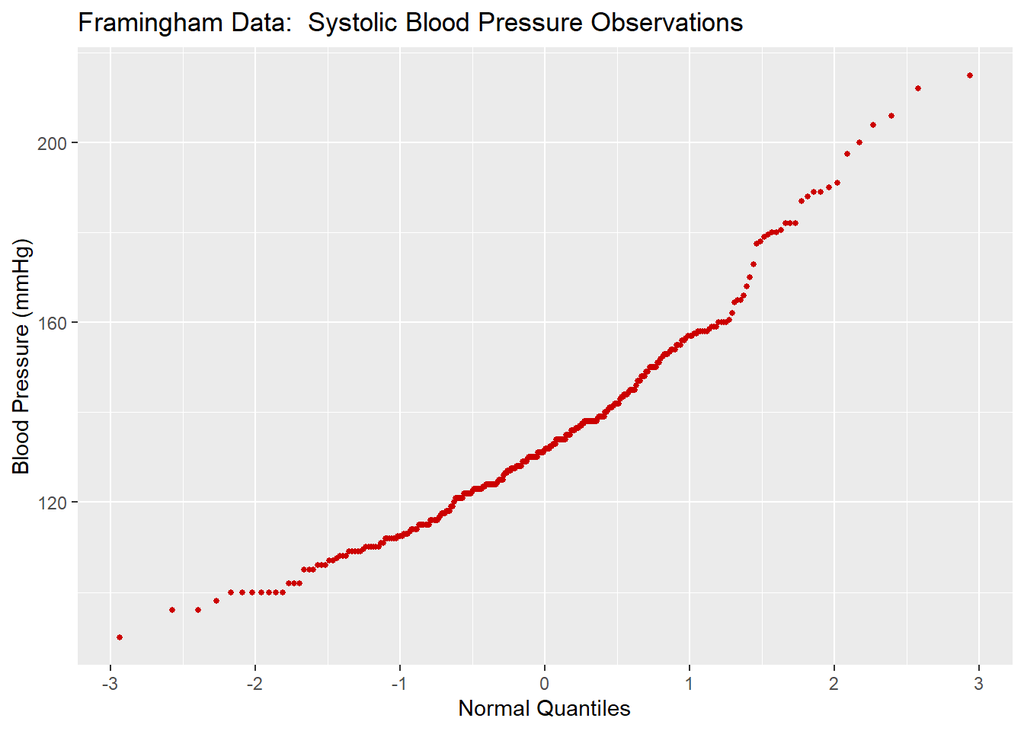

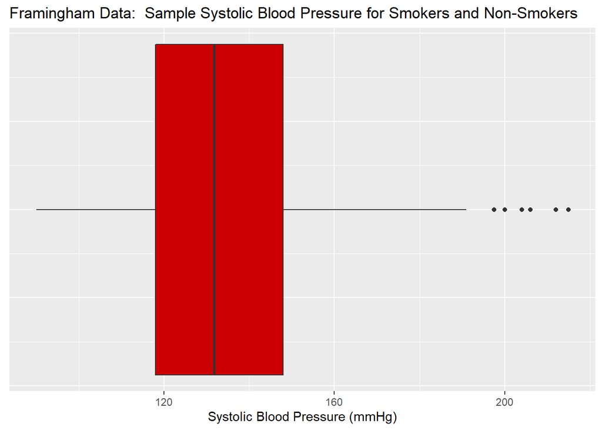

Visually summarizing the histogram above shows a skew toward the right as we can see several values inside the skew that might not be a good representation of the rest of the data points. The concerning values we think may be outliers are systolic blood pressure observations where the subject had a 180 mmHg reading or higher. A pressure observed above 180mmHg is consider a medical emergency and requires urgent care and hospitalization (Heart.org, 2017).

The Quantile-Quantile plot exhibits a linear tendency though variability in observations in the right tail may be distorting linearity. It is not enough to reject the normality assumption on this fact alone though purging outliers would serve to strengthen the argument in favor of assuming normality.

We produced a box-plot to examine the distribution and highlight outliers. We found six values that were outside of the interquartile multiplier range–five observations from the non-smokers sample and one observation from the smokers sample. We will report both t-tests with outliers and without outliers for comparison.

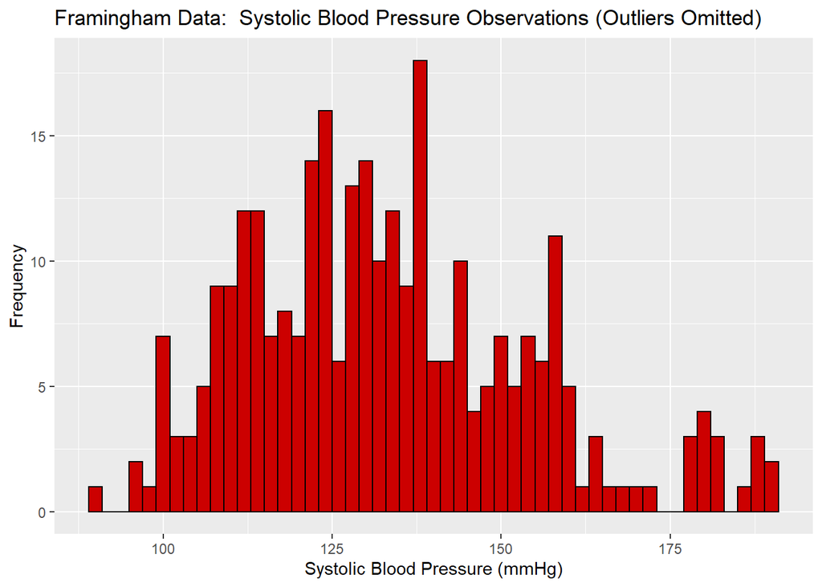

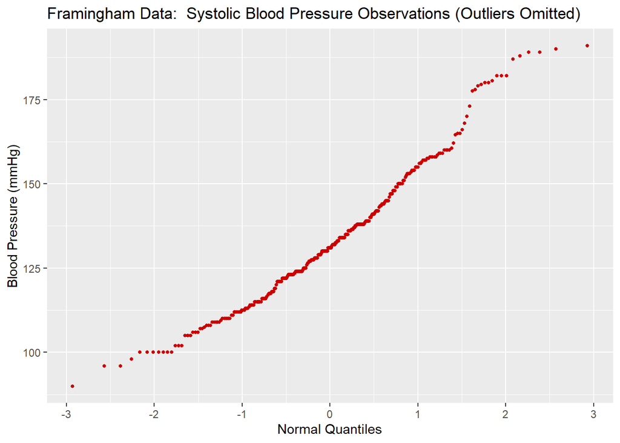

After removing the outliers we can observe that the histogram looks less skewed and more normalized in comparison to the histogram with outliers. The skew is gentler and better representative of the data overall. Likewise, the Q-Q plot appears slightly more linear than before with the tail in the upper end showing less variability, visually. The preliminary data analysis is complete and we are ready to use our t-tests to make inference on our sampled means.

#### Pooled T-test (outliers included)

##### **P-Value**

$H_{0}: \mu_{1}-\mu_{2} = 0$, There is no difference between means of smokers and non-smokers.  
$H_{0}: \mu_{1}-\mu_{2} ≠ 0$, There is a difference between means of smokers and non-smokers.  
$\bar{X}_{1} = \frac{1}{225}\sum(x_{1},x_{2},...,x_{225}) = 137.22444$  
$s^2_{1} = \frac{1}{225^2}\sum^{225}_{i=1}(x_{i}-\bar{x_{1}}) = 562.1447$  
$n_{1} = 225$  
$\bar{X}_{2} = \frac{1}{75}\sum(x_{1},x_{2},...,x_{75}) = 128.06667$  
$s^2_{2} = \frac{1}{75^2}\sum^{75}_{j=1}(x_{j}-\bar{x_{2}}) = 352.2117$  
$n_{2} = 75$  
$S^2_{p} = \frac{(n_{1}-1)S^2_{1}+(n_{2}-1)S^2_{2}}{n_{1}+n_{2}-2} = \frac{(225-1)562.1447+(75-1)352.2117}{225+75-2} = 510.01370$  
$S_{p} = \sqrt(S^2_{p}) = \sqrt(510.01370) = 22.58350$  
$T = \frac{\bar{X_{1}} - \bar{X_{2}}} {S_{p}\sqrt(\frac{1}{n_{1}}+\frac{1}{n_{2}})} = \frac{137.22444 - 128.06667} {22.5835\sqrt(\frac{1}{225}+\frac{1}{75})} = 3.0413$  
Under the null hypothesis, $H_{0}: T \sim t_{298}$. The rejection region for the test $H_{a}: \mu_{1}-\mu_{2} ≠ D_{0}:$  
Rejection Region: ${t_{obs} : |t_{obs}| > t_{\frac{\alpha}{2},df}}$  
Rejection Region: ${t_{obs} : |3.04131| > 1.96796}$  
P-Value (two-tailed):  
$2*(1-pt(T = 3.0413,df = n_{1}+n_{2}-2)) = 2*(1-0.9987) = 0.00258$

###### **Conclusion:**

Reject $H_{0}$. At the 0.05 significance level, there is sufficient evidence to support the claim that mean systolic blood pressure between smokers and non-smokers is different.

##### **Confidence Interval**

Lower_Bound  
$(\bar{X_{1}}-\bar{X_{2}}) - t_{(\frac{\alpha}{2},df)}(S_{p})(\sqrt(\frac{1}{n_{1}}+\frac{1}{n_{2}})) = (137.22444 - 128.06667) - (1.96796)(22.58350)(\sqrt(\frac{1}{225}+\frac{1}{75}) = 3.23194$  
Upper_Bound  
$(\bar{X_{1}}-\bar{X_{2}}) + t_{(\frac{\alpha}{2},df)}(S_{p})(\sqrt(\frac{1}{n_{1}}+\frac{1}{n_{2}})) = (137.22444 - 128.06667) + (1.96796)(22.58350)(\sqrt(\frac{1}{225}+\frac{1}{75}) = 15.0835$

###### **Conclusion:**

We are 95% confident that the mean difference in systolic blood pressure between smokers and non-smokers is between 3.23194 mmHg and 15.0835 mmHg.

#### Pooled T-test (outliers omitted)

##### **P-Value**

$H_{0}: \mu_{1}-\mu_{2} = 0$, There is no difference between means of smokers and non-smokers.  
$H_{0}: \mu_{1}-\mu_{2} ≠ 0$, There is a difference between means of smokers and non-smokers.  
$\bar{X}_{1} = \frac{1}{220}\sum(x_{1},x_{2},...,x_{220}) = 135.6409$  
$s^2_{1} = \frac{1}{220^2}\sum^{220}_{i=1}(x_{i}-\bar{x_{1}}) = 460.7586$  
$n_{1} = 220$  
$\bar{X}_{2} = \frac{1}{74}\sum(x_{1},x_{2},...,x_{74}) = 127.0946$  
$s^2_{2} = \frac{1}{74^2}\sum^{74}_{j=1}(x_{j}-\bar{x_{2}}) = 285.1964$  
$n_{2} = 74$  
$S^2_{p} = \frac{(n_{1}-1)S^2_{1}+(n_{2}-1)S^2_{2}}{n_{1}+n_{2}-2} = \frac{(22401)460.7586+(74-1)285.1964}{220+74-2} = 416.868$  
$S_{p} = \sqrt(S^2_{p}) = \sqrt(416.868) = 20.41735$  
$T = \frac{\bar{X_{1}} - \bar{X_{2}}} {S_{p}\sqrt(\frac{1}{n_{1}}+\frac{1}{n_{2}})} = \frac{135.6409 - 127.0946} {20.41735\sqrt(\frac{1}{220}+\frac{1}{74})} =3.1148$  
Under the null hypothesis, $H_{0}: T \sim t_{292}$. The rejection region for the test $H_{a}: \mu_{1}-\mu_{2} ≠ D_{0}:$  
Rejection Region: ${t_{obs} : |t_{obs}| > t_{\frac{\alpha}{2},df}}$  
Rejection Region: ${t_{obs} : |3.1148| > 1.968121}$

P-Value (two-tailed):  
$2*(1-pt(T = 3.1148,df = 220+74-2)) = 2*(1-0.99898) = 0.00204$

###### **Conclusion:**

Reject $H_{0}$. At the 0.05 significance level, there is sufficient evidence to support the claim that mean systolic blood pressure between smokers and non-smokers is different.

##### **Confidence Interval**

Lower_Bound  
$(\bar{X_{1}}-\bar{X_{2}}) - t_{(\frac{\alpha}{2},df)}(S_{p})(\sqrt(\frac{1}{n_{1}}+\frac{1}{n_{2}})) = (135.6409 - 127.0946) - (1.96796)(20.41735)(\sqrt(\frac{1}{220}+\frac{1}{74}) = 3.14669$  
Upper_Bound  
$(\bar{X_{1}}-\bar{X_{2}}) + t_{(\frac{\alpha}{2},df)}(S_{p})(\sqrt(\frac{1}{n_{1}}+\frac{1}{n_{2}})) = (135.6409 - 127.0946) + (1.96796)(20.41735)(\sqrt(\frac{1}{220}+\frac{1}{74}) = 13.9459$

###### **Conclusion:**

We are 95% confident that the mean difference in systolic blood pressure between smokers and non-smokers is between 3.14669 mmHg and 13.9459 mmHg.

#### Welch-Satterthwaite T-test (outliers included)

##### **P-Value**

For the Welch-Satterthwaite t-test we will test using the same hypothesis as in the t-test pooled; however, with the assumption about the variance removed, the test statistic formula.  
$H_{0}: \mu_{1}-\mu_{2} = 0$, There is no difference between means of smokers and non-smokers.  
$H_{0}: \mu_{1}-\mu_{2} ≠ 0$, There is a difference between means of smokers and non-smokers.  
$\bar{X}_{1} = \frac{1}{225}\sum(x_{1},x_{2},...,x_{225}) = 137.22444$  
$s^2_{1} = \frac{1}{225^2}\sum^{225}_{i=1}(x_{i}-\bar{x_{1}}) = 562.1447$  
$n_{1} = 225$  
$\bar{X}_{2} = \frac{1}{75}\sum(x_{1},x_{2},...,x_{75}) = 128.06667$  
$s^2_{2} = \frac{1}{75^2}\sum^{75}_{j=1}(x_{j}-\bar{x_{2}}) = 352.2117$  
$n_{2} = 75$  
$v = \frac{(\frac{s^2_{1}}{n_{1}}+\frac{s^2_{2}}{n_{2}})^2}{\frac{(\frac{s^2_{1}}{n_{1}})}{n_{1}-1}+{\frac{(\frac{s^2_{2}}{n_{2}})}{n_{2}-1}}} = \frac{(\frac{562.1447}{225}+\frac{352.2117}{75})^2}{\frac{(\frac{562.1447}{225})^2}{225-1}+{\frac{(\frac{352.2117}{75})^2}{75-1}}} = 158.8316$  
$T = \frac{\bar{X}_1-\bar{X}_2-D_{0}}{\sqrt(\frac{s^2_1}{n_{1}}+\frac{s^2_2}{n_{2}})} = \frac{137.22444-128.06667}{\sqrt(\frac{562.1447}{225}+\frac{352.2117}{75})} = 3.4142$  
Under the null hypothesis, $H_{0}: T \sim t_{v,\frac{\alpha}{2}} \sim t_{158.8316,0.025}$. The rejection region for the test $H_{a}: \mu_{1}-\mu_{2} ≠ D_{0}:$  
Rejection Region: ${t_{obs} : |t_{obs}| > t_{0.025,158}}$  
Rejection Region: ${t_{obs} : |3.4142| > 1.9751}$

###### **Conclusion:**

Reject $H_{0}$. At the 0.05 significance level, there is sufficient evidence to support the claim that mean systolic blood pressure between smokers and non-smokers is different.

##### **Confidence Interval**

Lower_Bound  
$(\bar{X_{1}}-\bar{X_{2}}) - t_{(\frac{\alpha}{2},v)}(\sqrt(\frac{S^2_{1}}{n_{1}}+\frac{S^2_{2}}{n_{2}})) = (137.22444 - 128.06667) - (1.975092)(\sqrt(\frac{562.1447}{225}+\frac{352.2117}{75}) = 3.86004$  
Upper_Bound  
$(\bar{X_{1}}-\bar{X_{2}}) + t_{(\frac{\alpha}{2},v)}(\sqrt(\frac{S^2_{1}}{n_{1}}+\frac{S^2_{2}}{n_{2}})) = (137.22444 - 128.06667) + (1.975092)(\sqrt(\frac{562.1447}{225}+\frac{352.2117}{75}) = 14.4555$

#### Welch-Satterthwaite T-test (outliers omitted)

##### **P-Value**

Rejection Region: ${t_{obs} : |t_{obs}| > t_{0.025,158}}$

Rejection Region: ${t_{obs} : |3.50412| > 1.9751}$

###### **Conclusion:**

Reject $H_{0}$. At the 0.05 significance level, there is sufficient evidence to support the claim that mean systolic blood pressure between smokers and non-smokers is different.

##### **Confidence Interval**

Lower_Bound  
$(\bar{X_{1}}-\bar{X_{2}}) - t_{(\frac{\alpha}{2},v)}(\sqrt(\frac{S^2_{1}}{n_{1}}+\frac{S^2_{2}}{n_{2}})) = (135.6409 - 127.0946) - (1.975092)(\sqrt(\frac{460.7586}{220}+\frac{285.1964}{74}) = 3.7292$

Upper_Bound  
$(\bar{X_{1}}-\bar{X_{2}}) + t_{(\frac{\alpha}{2},v)}(\sqrt(\frac{S^2_{1}}{n_{1}}+\frac{S^2_{2}}{n_{2}})) = (135.6409 - 127.0946) + (1.975092)(\sqrt(\frac{460.7586}{220}+\frac{285.1964}{74}) = 13.3634$

#### Discussion

Are the mean systolic blood pressures different between smokers and non-smokers? All four t-test concluded with the same result; a rejection of the null hypothesis. We found evidence in all four tests of evidence supporting a difference between systolic blood pressure means of participants who smoke versus those who do not.

An important step at the beginning of the analysis of our data was the identification of outliers. We were able to tighten-up the distribution by removing outliers through a box-plot. Once we saw several observations that extended beyond the whiskers of the plot, we calculated the interquartile range and calculated the minimum and maximum values of the whiskers. Any value exceeding the maximum were found and removed. We now have reorganized our data so that it became more representative of the population of Framingham, Massachusetts. The histogram return less skewed while the QQ plot returned more linear.

From the summary below we observe that the p-values for the Pooled t-tests would result in rejecting the null hypothesis but were closer to the significance alpha of 0.05 than those from the Satterthwaite t-tests. Those tests with outliers were closer to the significance alpha of 0.05 than those p-values from the same tests without the outliers. What we are finding is that if we were to take many samples, on average we would find that samples would result in rejecting the null hypothesis more frequently in Satterthwaite t-tests and pooled t-tests. We would would also reject more often with many samples where outliers were omitted than if they were to remain.

| Test Type | P-Value |
| --- | --- |
| t-Test pooled with outliers | 0.00258 |
| t-Test pooled without outliers | 0.00204 |
| t-Test Satterthwaite with outliers | 0.00073 |
| t-Test Satterthwaite without outliers | 0.00053 |

| Test Type | Lower Bound | Upper Bound |
| --- | --- | --- |
| t-Test pooled with outliers | 3.23194 | 15.0835 |
| t-Test pooled without outliers | 3.14669 | 13.9459 |
| t-Test Satterthwaite with outliers | 3.86004 | 14.4555 |
| t-Test Satterthwaite without outliers | 3.7292 | 13.3634 |

I would have chosen the Satterthwaite t-Test with outliers as my next option. The assumption of equal variance has a enormous impact on the testing results and it manifested in our work as higher p-values and wider confidence interval ranges.

## **Bootstrapping**

Another effective means of estimating a population parameter is the bootstrapping method. To model the Framingham Heart Study data and their means using this method, we will draw samples from the study and make inference based on those samples. Computer software does the heavy lifting for this exercise as the iterations require randomization of normality and many calculations.

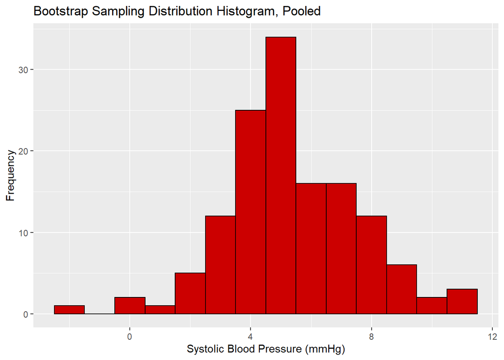

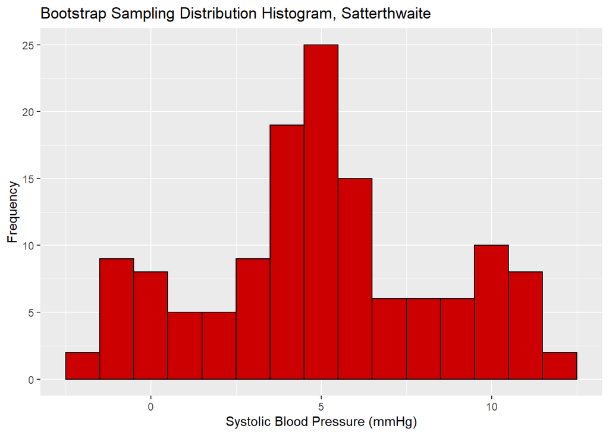

Our loop generated many simulated samples of smokers and non-smokers datasets and then processed each group under the conditions of a pooled t-test. A second iteration captured the Satterthwaite variant. We plotted the changes in power when the variance changed, the sample size changed and when the difference in means changed. We found that as the variance increase the power decreased. We also observed an increase in power as N1/N2 increased. When the difference between means grew larger, so did the power.

##### **t-Test Pooled Facet grids containing power variability.**

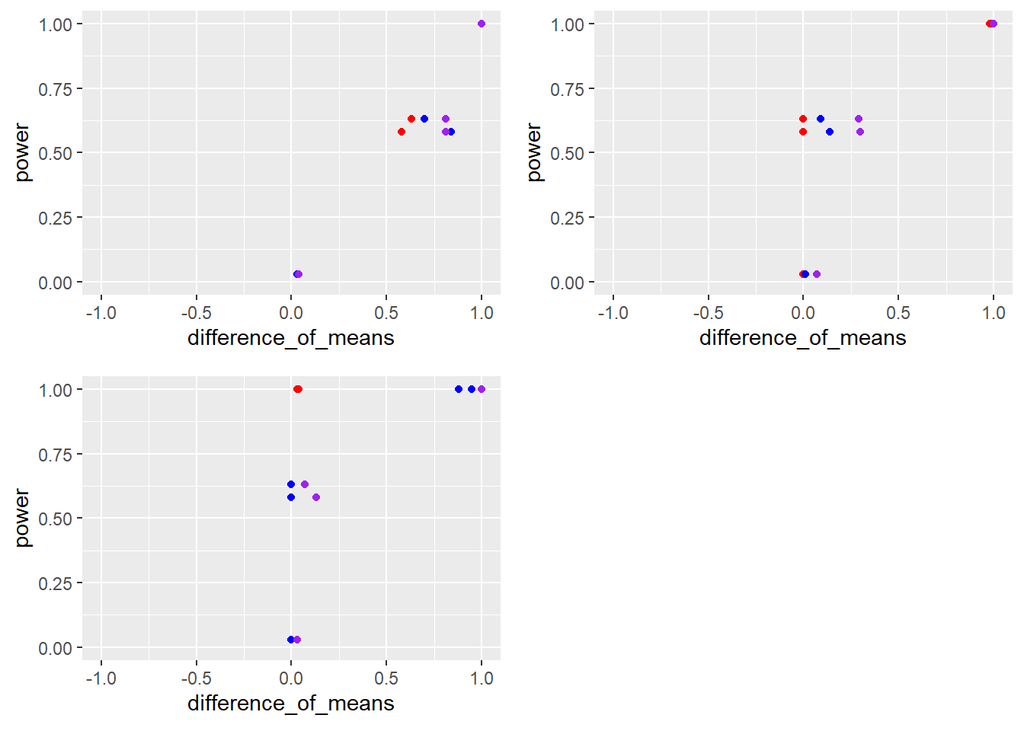

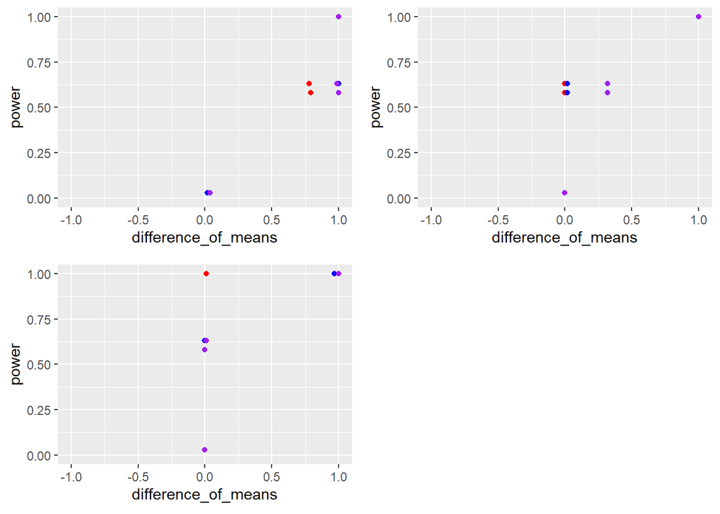

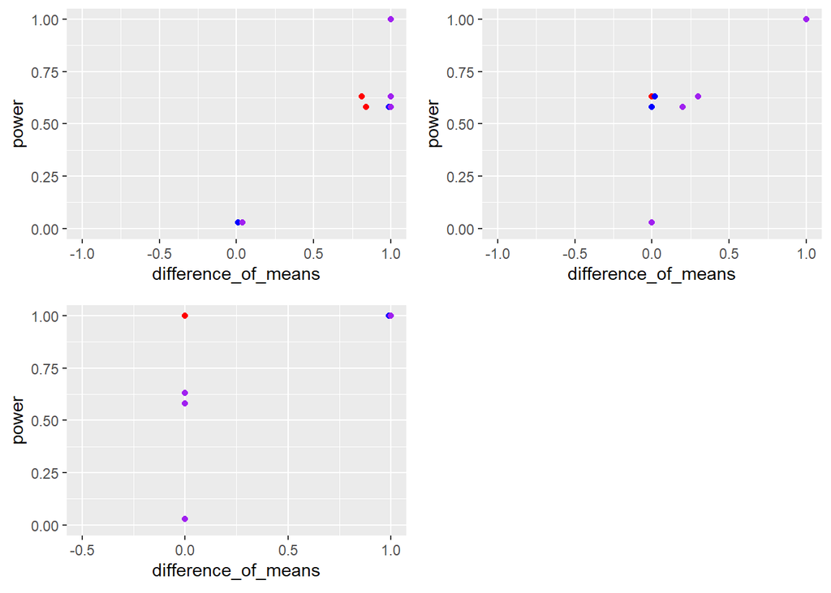

We can see the power increase in rate as we consider each increasing N2 value. The data points migrate to the center and one of the points reaches capacity.

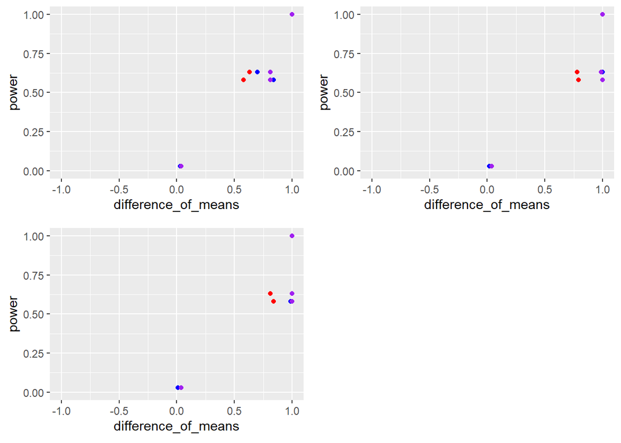

Power Plot when S1 = 1 and all other values held constant

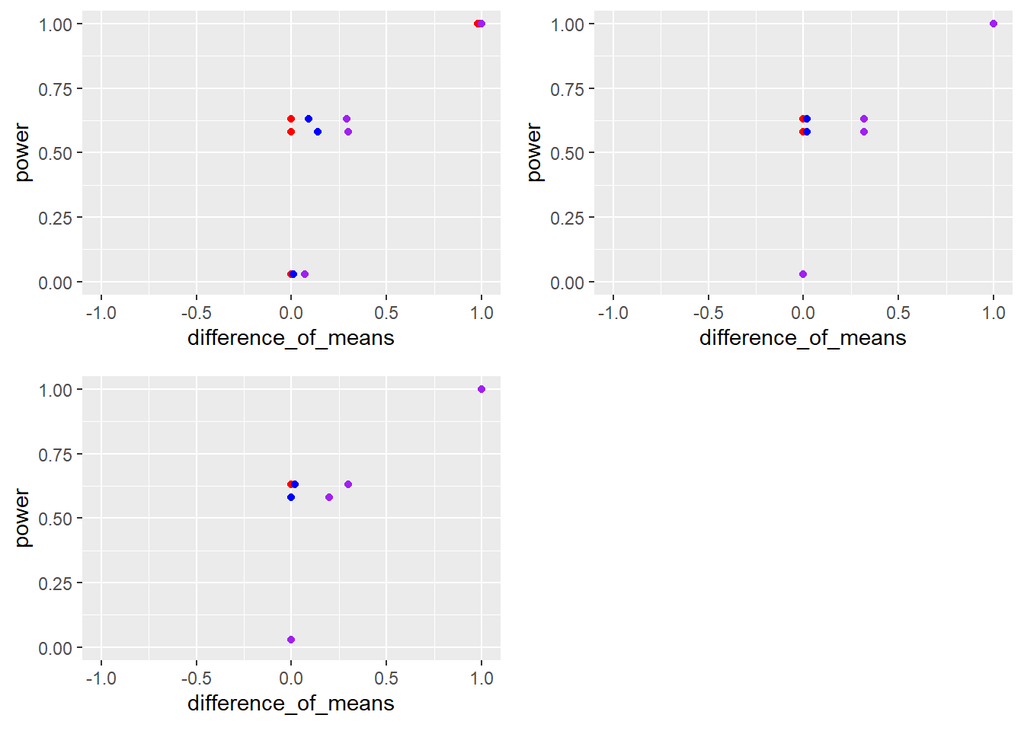

Power Plot when S1 = 4 and all other values held constant

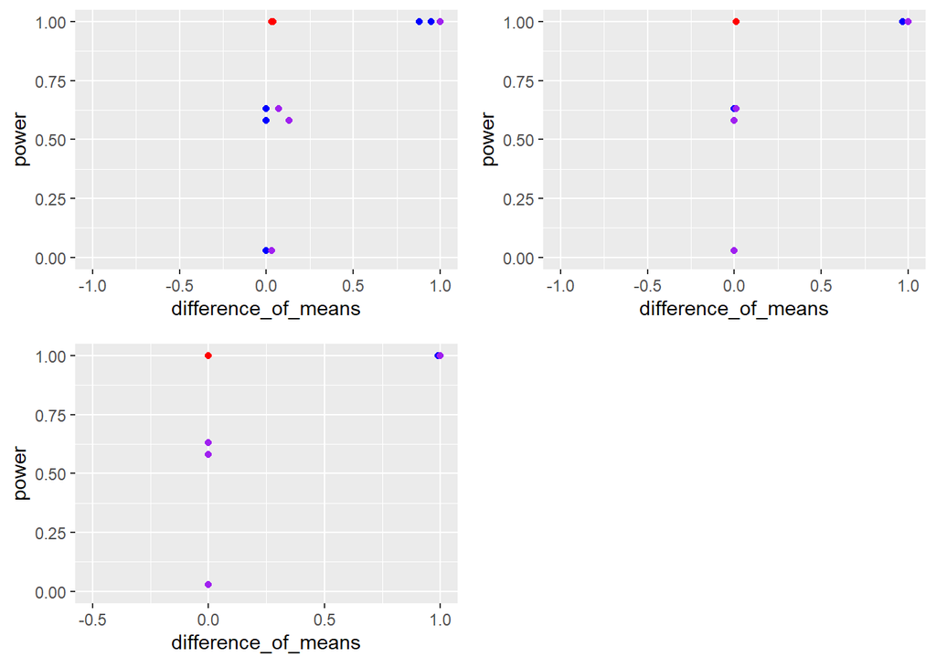

Power Plot when S1 = 9 and all other values held constant

##### **Satterthwaite Facet grids containing power variability.**

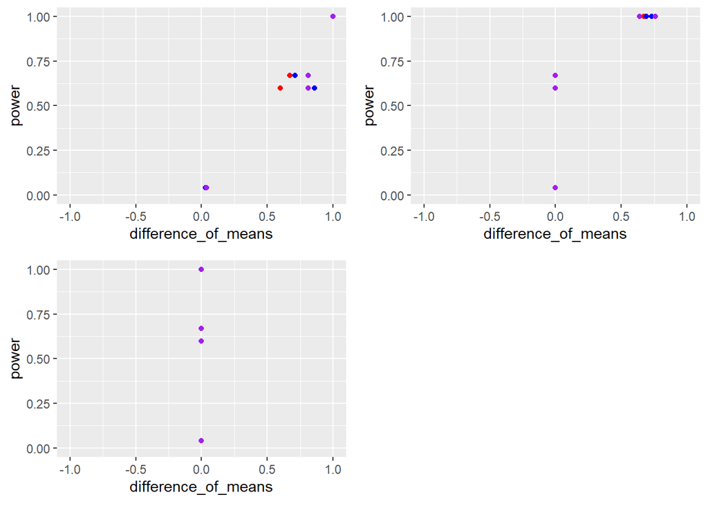

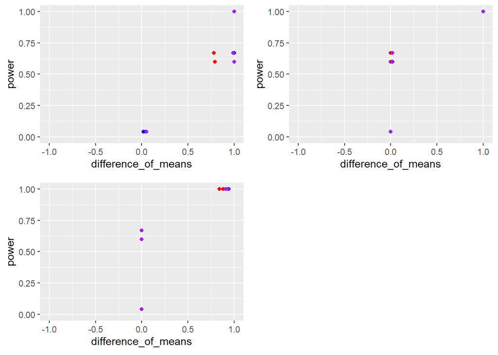

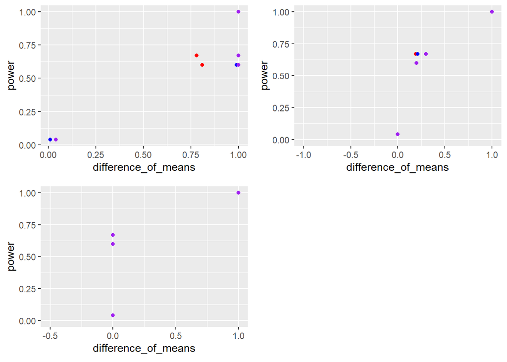

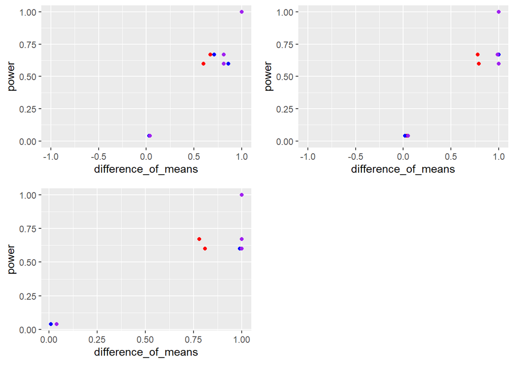

Power Plot when S1 = 1 and all other values held constant

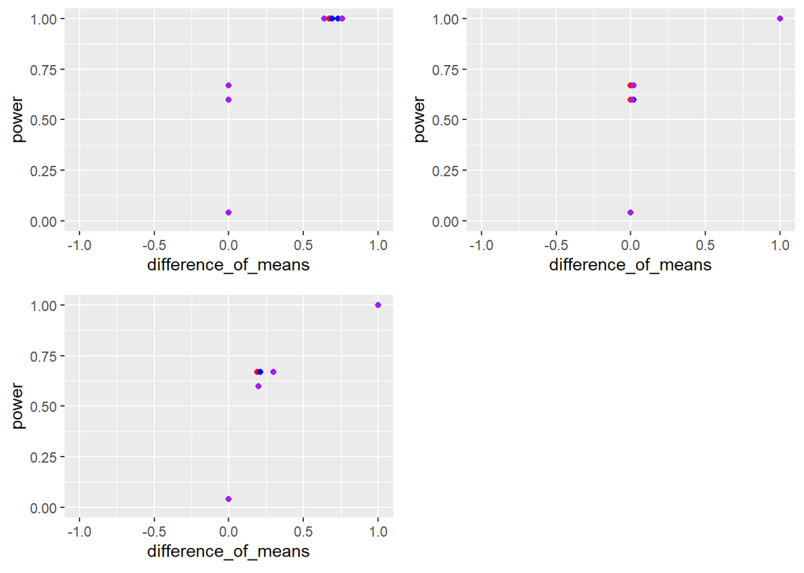

Power Plot when S1 = 4 and all other values held constant

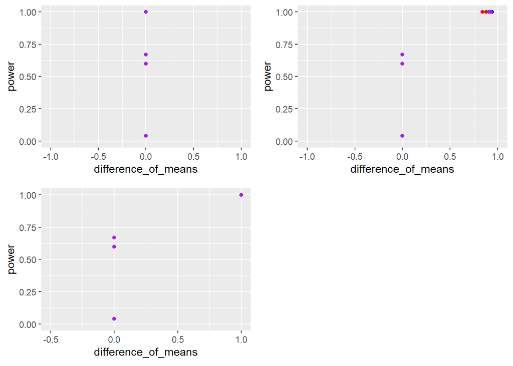

Power Plot when S1 = 9 and all other values held constant

##### **Confidence Interval for Bootstrapping**

Finally, we captured the confidence interval of our sampling distribution by finding the middle 95% of our distribution.

[output not shown]

##### Bibliography

Burke GM, Genuardi M, Shappell H, D’Agostino RB Sr, Magnani JW. Temporal Associations Between Smoking and Cardiovascular Disease, 1971 to 2006 (from the Framingham Heart Study). Am J Cardiol. 2017;120(10):1787-1791. doi:10.1016/j.amjcard.2017.07.087

Hypertensive Crisis: When You Should Call 9-1-1 for High Blood Pressure. (2017). Www.heart.org. https://www.heart.org/en/health-topics/high-blood-pressure/understanding-blood-pressure-readings/hypertensive-crisis-when-you-should-call-911-for-high-blood-pressure

Mayo Clinic. (2018). High blood pressure (hypertension) - Diagnosis and treatment. Mayoclinic.org. https://www.mayoclinic.org/diseases-conditions/high-blood-pressure/diagnosis-treatment/drc-20373417

Centers for Disease Control and Prevention. (2017, February 9). Health Effects of Smoking and Tobacco Use. Centers for Disease Control and Prevention. https://www.cdc.gov/tobacco/basic_information/health_effects/index.htm#:~:text=Smoking%20causes%20cancer%2C%20heart%20disease

##### **R CODE**

Plot code

```r
#Histogram with outliers
ggplot(framingham_data,mapping = aes(`sysBP`)) +
  geom_histogram(binwidth = 2, fill="#CC0000", color="#000000") +
  labs(title="Framingham Data:  Systolic Blood Pressure Observations", y="Frequency", x="Systolic Blood Pressure (mmHg)")

#QQ-plot with outliers
ggplot(framingham_data, mapping = aes(sample = framingham_data$sysBP)) +
  geom_qq(size = 1, fill="#CC0000", color="#CC0000") +
  labs(title="Framingham Data:  Systolic Blood Pressure Observations", y="Blood Pressure (mmHg)", x="Normal Quantiles")

#Boxplot with outliers
ggplot(framingham_data, mapping = aes(x=`sysBP`)) +
  geom_boxplot(fill="#CC0000") +
  labs(title="Framingham Data:  Sample Systolic Blood Pressure for Smokers and Non-Smokers", x="Systolic Blood Pressure (mmHg)") +
  theme(axis.text.y=element_blank(),
        axis.ticks.y=element_blank())

#Historgram post outliers
ggplot(framingham_data_no_outlier,mapping = aes(`sysBP`)) +
  geom_histogram(binwidth = 2, fill="#CC0000", color="#000000") +
  labs(title="Framingham Data:  Systolic Blood Pressure Observations (Outliers Omitted)", y="Frequency", x="Systolic Blood Pressure (mmHg)")

#QQ-plot post outliers
ggplot(framingham_data_no_outlier, mapping = aes(sample = `sysBP`)) +
  geom_qq(size = 1, fill="#CC0000", color="#CC0000") +
  labs(title="Framingham Data:  Systolic Blood Pressure Observations (Outliers Omitted)", y="Blood Pressure (mmHg)", x="Normal Quantiles")
```

Pooled T-Test (Outliers Included)

```r
#Variable Naming Convention:  <SampledGroup>_<content>_<specialcondition>
#Code until break contains t-test pooled values for p-value with outliers
NS_RawData_OL <- framingham_data[currentSmoker==0,2] #Grouped non-smokers together with outliers
S_RawData_OL <- framingham_data[currentSmoker==1,2] #Grouped smokers together with outliers

NS_RawData_OL <- unlist(framingham_data[currentSmoker==0,2])
NS_Mean_OL <- mean(NS_RawData_OL) #Mean systolic blood pressure of non-smokers with outliers

S_RawData_OL = unlist(framingham_data[currentSmoker==1,2])
S_Mean_OL = mean(S_RawData_OL) #Mean systolic blood pressure of smokers with outliers

NS_STDDEV_OL = sd(NS_RawData_OL) #Standard deviation systolic blood pressure for non-smokers with outliers
S_STDDEV_OL = sd(S_RawData_OL) #Standard deviation systolic blood pressure for smokers with outliers

NS_OBS_OL = length(NS_RawData_OL) #number of non-smokers in the sample with outliers
S_OBS_OL = length(S_RawData_OL) #number of non-smokers in the sample with outliers

SNS_WgtAve_OL = ((NS_OBS_OL-1)*NS_STDDEV_OL^2 + (S_OBS_OL-1)*S_STDDEV_OL^2)/(NS_OBS_OL+S_OBS_OL-2) #Weighted average of combined sample variances as a measure squared with outliers
SNS_TStat_OL = (NS_Mean_OL - S_Mean_OL)/(sqrt(SNS_WgtAve_OL)*sqrt(1/NS_OBS_OL + 1/S_OBS_OL)) #Test statistic for the t-test pooled with outliers.
SNS_PVAL_OL <- 2*(1-pt(3.04,298)) #P-Value for a two tailed t-test with degrees of freedom 3.04131 and 298.




#Code until break contains t-test pooled values for Confidence Interval test method with outliers
SNS_Crit_OL <- qt(0.025,298)

Lower_Bound_OL <- (NS_Mean_OL - S_Mean_OL) - (SNS_Crit_OL)*(sqrt(SNS_WgtAve_OL)*sqrt(1/NS_OBS_OL + 1/S_OBS_OL)) #Lower Bound of the Confidence Interval test for the difference of means with outliers

Upper_Bound_OL <- (NS_Mean_OL - S_Mean_OL) + (SNS_Crit_OL)*(sqrt(SNS_WgtAve_OL)*sqrt(1/NS_OBS_OL + 1/S_OBS_OL)) #Upper Bound of the Confidence Interval test for the difference of means with outliers
```

Pooled T-Test (Outliers Omitted)

```r
#Code until break contains t-test pooled values for p-value with no outliers
NS_RawData_NoOL <- framingham_data[currentSmoker==0,2] #Grouped non-smokers together with no outliers
S_RawData_NoOL <- framingham_data[currentSmoker==1,2] #Grouped smokers together with no outliers

NS_RawData_NoOL <- unlist(framingham_data[currentSmoker==0,2])
NS_Mean_NoOL <- mean(NS_RawData_NoOL) #Mean systolic blood pressure of non-smokers with no outliers

S_RawData_NoOL = unlist(framingham_data[currentSmoker==1,2])
S_Mean_NoOL = mean(S_RawData_NoOL) #Mean systolic blood pressure of smokers with no outliers

NS_STDDEV_NoOL = sd(NS_RawData_NoOL) #Standard deviation systolic blood pressure for non-smokers with no outliers
S_STDDEV_NoOL = sd(S_RawData_NoOL) #Standard deviation systolic blood pressure for smokers with no outliers

NS_OBS_NoOL = length(NS_RawData_NoOL) #number of non-smokers in the sample with no outliers
S_OBS_NoOL = length(S_RawData_NoOL) #number of non-smokers in the sample with no outliers

SNS_WgtAve_NoOL = ((NS_OBS_NoOL-1)*NS_STDDEV_NoOL^2 + (S_OBS_NoOL-1)*S_STDDEV_NoOL^2)/(NS_OBS_NoOL+S_OBS_NoOL-2) #Weighted average of combined sample variances as a measure squared with no outliers
SNS_TStat_NoOL = (NS_Mean_NoOL - S_Mean_NoOL)/(sqrt(SNS_WgtAve_NoOL)*sqrt(1/NS_OBS_NoOL + 1/S_OBS_NoOL)) #Test statistic for the t-test pooled with no outliers.
SNS_PVAL_NoOL <- 2*(1-pt(3.04,298)) #P-Value for a two tailed t-test with degrees of freedom 3.04131 and 298.




#Code until break contains t-test pooled values for Confidence Interval test method with no outliers
SNS_Crit_NoOL <- qt(0.025,298)

Lower_Bound_NoOL <- (NS_Mean_NoOL - S_Mean_NoOL) - (SNS_Crit_NoOL)*(sqrt(SNS_WgtAve_NoOL)*sqrt(1/NS_OBS_NoOL + 1/S_OBS_NoOL)) #Lower Bound of the Confidence Interval test for the difference of means with no outliers

Upper_Bound_NoOL <- (NS_Mean_NoOL - S_Mean_NoOL) + (SNS_Crit_NoOL)*(sqrt(SNS_WgtAve_NoOL)*sqrt(1/NS_OBS_NoOL + 1/S_OBS_NoOL)) #Upper Bound of the Confidence Interval test for the difference of means with no outliers
```

Welch-Satterthwaite T-test (Outliers Included)

```r
SNS_TStat_OL_SW <- (NS_Mean_OL-S_Mean_OL)/sqrt((NS_STDDEV_OL/NS_OBS_OL)+(S_STDDEV_OL/S_OBS_OL)) #Test Statistic for non equal variance with outliers.
v <- (((NS_STDDEV_OL/NS_OBS_OL)+(S_STDDEV_OL/S_OBS_OL))^2)/(((NS_STDDEV_OL/NS_OBS_OL)^2/(NS_OBS_OL-1))+(S_STDDEV_OL/S_OBS_OL)^2/(S_OBS_OL-1)) #Degrees of Freedom
```

Welch-Satterthwaite T-test (Outliers Omitted)

```r
SNS_TStat_NoOL_SW <- (NS_Mean_NoOL-S_Mean_NoOL)/sqrt((NS_STDDEV_NoOL/NS_OBS_NoOL)+(S_STDDEV_NoOL/S_OBS_NoOL)) #Test Statistic for non equal variance with outliers.
v <- (((NS_STDDEV_NoOL/NS_OBS_NoOL)+(S_STDDEV_NoOL/S_OBS_NoOL))^2)/(((NS_STDDEV_NoOL/NS_OBS_NoOL)^2/(NS_OBS_NoOL-1))+(S_STDDEV_NoOL/S_OBS_NoOL)^2/(S_OBS_NoOL-1)) #Degrees of Freedom
```

Bootstrapping

```r
#Setting Parameters
N1 <- c(10,30,70) #Sample Size from Sample_1
N2 <- c(10,30,70) #Sample Size from Sample_2
MU2 <- c(5, 10, 6, 4, 0) #mu1 fixed to a value of 5 such that the mean difference u1-u2 = c(0,-5, -1, 1, 5) would create this vector of MU2 values.
S1 <- c(1, 4, 9) #Variance of Sample_1
B = 100 #Replicating 100 times
alpha = 0.05 #Significance Level
result1 = matrix(0, nr=135, nc=B)  #setting matrix to record p-values for equal variance where there are 135 cases so 135 rows and 100 replications
result2 = matrix(0, nr=135, nc=B)  #setting matrix to record p-values for unequal variance where there are 135 cases so 135 rows and 100 replications


#Dummy Matrix Creation
para = matrix(0, nr=135, nc=4)  #4 parameters c("N1", "N2", "S1", "Mu2")
pvalueresults1 = matrix(0, nr=135, nc=B) #pvalue1 capture matrix dim(135,100)
pvalueresults2 = matrix(0, nr=135, nc=B) #pvalue1 capture matrix dim(135,100)
Y1Results = matrix(0, nr=135) #rnorm_1 capture matrix dim(135,100)
Y2Results = matrix(0, nr=135) #rnorm_2 capture matrix dim(135,100)

#The "para" set are the combinatorics for each of the cases of paramaterization that we will evaluate.  Each para below captures a block of terms evaluated with a changing variable.
para[1:5,1]=10;     para[1:5,2]=10;     para[1:5,3]=1;      para[1:5,4]=MU2
para[6:10,1]=10;    para[6:10,2]=30;    para[6:10,3]=1;     para[6:10,4]=MU2
para[11:15,1]=10;   para[11:15,2]=70;   para[11:15,3]=1;    para[11:15,4]=MU2
para[16:20,1]=10;   para[16:20,2]=10;   para[16:20,3]=4;    para[16:20,4]=MU2
para[21:25,1]=10;   para[21:25,2]=30;   para[21:25,3]=4;    para[21:25,4]=MU2
para[26:30,1]=10;   para[26:30,2]=70;   para[26:30,3]=4;    para[26:30,4]=MU2
para[31:35,1]=10;   para[31:35,2]=10;   para[31:35,3]=9;    para[31:35,4]=MU2
para[36:40,1]=10;   para[36:40,2]=30;   para[36:40,3]=9;    para[36:40,4]=MU2
para[41:45,1]=10;   para[41:45,2]=70;   para[41:45,3]=9;    para[41:45,4]=MU2
para[46:50,1]=30;   para[46:50,2]=10;   para[46:50,3]=1;    para[46:50,4]=MU2
para[51:55,1]=30;   para[51:55,2]=30;   para[51:55,3]=1;    para[51:55,4]=MU2
para[56:60,1]=30;   para[56:60,2]=70;   para[56:60,3]=1;    para[56:60,4]=MU2
para[61:65,1]=30;   para[61:65,2]=10;   para[61:65,3]=4;    para[61:65,4]=MU2
para[66:70,1]=30;   para[66:70,2]=30;   para[66:70,3]=4;    para[66:70,4]=MU2
para[71:75,1]=30;   para[71:75,2]=70;   para[71:75,3]=4;    para[71:75,4]=MU2
para[76:80,1]=30;   para[76:80,2]=10;   para[76:80,3]=9;    para[76:80,4]=MU2
para[81:85,1]=30;   para[81:85,2]=30;   para[81:85,3]=9;    para[81:85,4]=MU2
para[86:90,1]=30;   para[86:90,2]=70;   para[86:90,3]=9;    para[86:90,4]=MU2
para[91:95,1]=70;   para[91:95,2]=10;   para[91:95,3]=1;    para[91:95,4]=MU2
para[96:100,1]=70;  para[96:100,2]=30;  para[96:100,3]=1;   para[96:100,4]=MU2
para[101:105,1]=70; para[101:105,2]=70; para[101:105,3]=1;  para[101:105,4]=MU2
para[106:110,1]=70; para[106:110,2]=10; para[106:110,3]=4;  para[106:110,4]=MU2
para[111:115,1]=70; para[111:115,2]=30; para[111:115,3]=4;  para[111:115,4]=MU2
para[116:120,1]=70; para[116:120,2]=70; para[116:120,3]=4;  para[116:120,4]=MU2
para[121:125,1]=70; para[121:125,2]=10; para[121:125,3]=9;  para[121:125,4]=MU2
para[126:130,1]=70; para[126:130,2]=30; para[126:130,3]=9;  para[126:130,4]=MU2
para[131:135,1]=70; para[131:135,2]=70; para[131:135,3]=9;  para[131:135,4]=MU2

set.seed(0821)
for(i in 1:135){ #for loop to go through each case
  sigma1 = para[i,3]; #invokes the different evaluations of the variance terms
  sigma2 = 1; #variance_2 was said to be evaluated at a constant of 1.
  n1 = para[i,1]; #invokes the different evaluations of sample size of n_1
  n2 = para[i,2]; #invokes the different evaluations of sample size of n_1
  mu1 = 5; #u1 was said to evaluated at a constant of 5
  mu2 = para[i,4]; #invokes the different evaluations of mu2

  for(b in 1:B){
    Y1 = rnorm(n1, mu1, sqrt(sigma1)) #Creates a normal distribution using parameters outlined in assumptions
    Y1Results[i] <- Y1 #Save Y1 results to the Y1Results matrices
    Y2 = rnorm(n2, mu2, sqrt(sigma2)) #Creates a normal distribution using parameters outlined in assumptions
    Y2Results[i] <- Y2 #Save Y2 results to the Y2Results matrices

    #Evaluation of the Pooled
    meanY1 = mean(Y1) #Takes a mean of the normal distribution and saves it to meanY1
    meanY2 = mean(Y2) #Takes a mean of the normal distribution and saves it to meanY2
    Sp_2 = ((n1-1)*sigma1^2 + (n2-1)*sigma2^2)/(n1+n2-2) #Pooled Variance multiplier
    T_1 = abs(meanY1-meanY2)/(sqrt(Sp_2)*sqrt(1/n1 + 1/n2)) #equal variance test statistic (mean has to come from true value not sample data)
    df_1 = n1 + n2 - 2 #Degrees of Freedom
    pvalue1 = 2*(1-pt(T_1, df_1)) #equal variance p-value
    pvalueresults1[i] <- pvalue1 #saves the p-value to one of our dummy matrices

    #Evaluation of the Satterthwaite
    T_2 = abs(meanY1-meanY2)/(sqrt((sigma1^2/n1)+(sigma2^2/n2))) #unequal variance t-test statistic
    df_2 = ((sigma1^2/n1)+(sigma2^2/n2)^2)/((((sigma1^2/n1)^2)/(n1-1) + (((sigma2^2/n2)^2)/(n2-1)))) #Unequal variance Degrees of Freedom
    pvalue2 = 2*(1-pt(T_2, df_2)) #Unequal variance p-value
    pvalueresults2[i] <- pvalue2 #saves the p-value to one of our dummy matrices


    if(pvalue1 <= alpha){  # checking if p-value for equal variance test is less than or equal to alpha
      result1[i, b] = 1    # recording number of rejections where ith row corresponds to ith situation/combination/scenario
    } else{                # if p-value is greater than alpha
      result1[i, b] = 0    # recording number of fail to rejections
    }
    if(pvalue2 <= alpha){  # testing if p-value for unequal variance test is less than or equal to alpha
      result2[i, b] = 1    # recording number of rejections
    } else{                # if p-value is greater than alpha
      result2[i, b] = 0    # recording number of fail to rejections
    }
  }

}

Type1error_1 <- rowMeans(result1)  #this is type1error for the equal variance test and is the mean/proportion of results recorded of 100 samples
Type1error_2 <- rowMeans(result2)  #this is type1error for the unequal variance test and is the mean/proportion of results recorded of 100 samples

Y1Results <- as.data.frame(Y1Results) #Saves Y1Results as a data.frame to be used in ggplot2
Y2Results <- as.data.frame(Y2Results) #Saves Y2Results as a data.frame to be used in ggplot2

#Confidence Interval for the Y1
    Y1mean <- mean(Y1) #Mean of Y1
    Y1sd <- sd(Y1) #Standard Deviation of Y1
    Y1_lb <- Y1mean - 2*(Y1sd) #Lower Bound CI of Y1
    Y1_ub <- Y1mean + 2*(Y1sd) #Upper Bound CI of Y1

    Y2mean <- mean(Y2) #Mean of Y2
    Y2sd <- sd(Y2) #Standard Deviation of Y2
    Y2_lb <- Y2mean - 2*(Y2sd) #Lower Bound CI of Y2
    Y2_ub <- Y2mean + 2*(Y2sd) #Upper Bound CI of Y2
```

```r
data1 <- data.frame(difference_of_means=c(0, -5, -1, 1, 5), power=c(Type1error_1[1:5]))
one = ggplot(data=data1, mapping=aes(x=difference_of_means, y=power)) +
  geom_point(mapping=aes(Type1error_1[1:5]), color='red') + #where n1=10, n2=10, s1=1
  geom_point(mapping=aes(Type1error_1[6:10]), color='blue') + #where n1=10, n2=30, s1=1
  geom_point(mapping=aes(Type1error_1[11:15]), color='purple') + #where n1=10, n2=70, s1=1
  #facet_grid(Type1error_1[1:5]) +
  ylim(c(0,1)) +
  xlim(c(-1,1)) +
  #main="Plot for case n1=10, n2=10,30,70 and s1=1" +
  xlab(expression(difference_of_means))
data2 <- data.frame(difference_of_means=c(0, -5, -1, 1, 5), power=c(Type1error_1[1:5]))
two = ggplot(data=data2, mapping=aes(x=difference_of_means, y=power)) +
  geom_point(mapping=aes(Type1error_1[16:20]), color="red") + #where n1=10, n2=10, s1=4
  geom_point(mapping=aes(Type1error_1[21:25]), color="blue") + #where n1=10, n2=30, s1=4
  geom_point(mapping=aes(Type1error_1[26:30]), color="purple") + #where n1=10, n2=70, s1=4
  ylim(c(0,1)) +
  xlim(c(-1,1)) +
  xlab(expression(difference_of_means))
data3 <- data.frame(difference_of_means=c(0, -5, -1, 1, 5), power=c(Type1error_1[1:5]))
three = ggplot(data=data3, mapping=aes(x=difference_of_means, y=power)) +
  geom_point(mapping=aes(Type1error_1[31:35]), color="red") + #where n1=10, n2=10, s1=9
  geom_point(mapping=aes(Type1error_1[36:40]), color="blue") + #where n1=10, n2=30, s1=9
  geom_point(mapping=aes(Type1error_1[41:45]), color="purple") + #where n1=10, n2=70, s1=9
  ylim(c(0,1)) +
  xlim(c(-1,1)) +
  xlab(expression(difference_of_means))
data4 <- data.frame(difference_of_means=c(0, -5, -1, 1, 5), power=c(Type1error_1[1:5]))
four = ggplot(data=data4, mapping=aes(x=difference_of_means, y=power)) +
  geom_point(mapping=aes(Type1error_1[46:50]), color="red") + #where n1=30, n2=10, s1=1
  geom_point(mapping=aes(Type1error_1[51:55]), color="blue") + #where n1=30, n2=30, s1=1
  geom_point(mapping=aes(Type1error_1[56:60]), color="purple") + #where n1=30, n2=70, s1=1
  ylim(c(0,1)) +
  xlim(c(-1,1)) +
  xlab(expression(difference_of_means))
data5 <- data.frame(difference_of_means=c(0, -5, -1, 1, 5), power=c(Type1error_1[1:5]))
five = ggplot(data=data5, mapping=aes(x=difference_of_means, y=power)) +
  geom_point(mapping=aes(Type1error_1[61:65]), color="red") + #where n1=30, n2=10, s1=4
  geom_point(mapping=aes(Type1error_1[66:70]), color="blue") + #where n1=30, n2=30, s1=4
  geom_point(mapping=aes(Type1error_1[71:75]), color="purple") + #where n1=30, n2=70, s1=4
  ylim(c(0,1)) +
  xlim(c(-1,1)) +
  xlab(expression(difference_of_means))
data6 <- data.frame(difference_of_means=c(0, -5, -1, 1, 5), power=c(Type1error_1[1:5]))
six = ggplot(data=data6, mapping=aes(x=difference_of_means, y=power)) +
  geom_point(mapping=aes(Type1error_1[76:80]), color="red") + #where n1=30, n2=10, s1=9
  geom_point(mapping=aes(Type1error_1[81:85]), color="blue") + #where n1=30, n2=30, s1=9
  geom_point(mapping=aes(Type1error_1[86:90]), color="purple") + #where n1=30, n2=70, s1=9
  ylim(c(0,1)) +
  xlim(c(-1,1)) +
  xlab(expression(difference_of_means))
data7 <- data.frame(difference_of_means=c(0, -5, -1, 1, 5), power=c(Type1error_1[1:5]))
seven = ggplot(data=data7, mapping=aes(x=difference_of_means, y=power)) +
  geom_point(mapping=aes(Type1error_1[91:95]), color="red") + #where n1=70, n2=10, s1=1
  geom_point(mapping=aes(Type1error_1[96:100]), color="blue") + #where n1=70, n2=30, s1=1
  geom_point(mapping=aes(Type1error_1[101:105]), color="purple") + #where n1=70, n2=70, s1=1
  ylim(c(0,1)) +
  xlim(c(-1,1)) +
  xlab(expression(difference_of_means))
data8 <- data.frame(difference_of_means=c(0, -5, -1, 1, 5), power=c(Type1error_1[1:5]))
eight = ggplot(data=data8, mapping=aes(x=difference_of_means, y=power)) +
  geom_point(mapping=aes(Type1error_1[106:110]), color="red") + #where n1=70, n2=10, s1=4
  geom_point(mapping=aes(Type1error_1[111:115]), color="blue") + #where n1=70, n2=30, s1=4
  geom_point(mapping=aes(Type1error_1[116:120]), color="purple") + #where n1=70, n2=70, s1=4
  ylim(c(0,1)) +
  xlim(c(-1,1)) +
  xlab(expression(difference_of_means))
data9 <- data.frame(difference_of_means=c(0, -5, -1, 1, 5), power=c(Type1error_1[1:5]))
nine = ggplot(data=data9, mapping=aes(x=difference_of_means, y=power)) +
  geom_point(mapping=aes(Type1error_1[121:125]), color="red") + #where n1=70, n2=10, s1=9
  geom_point(mapping=aes(Type1error_1[126:130]), color="blue") + #where n1=70, n2=30, s1=9
  geom_point(mapping=aes(Type1error_1[131:135]), color="purple") + #where n1=70, n2=70, s1=9
  ylim(c(0,1)) +
  xlim(c(-0.5 ,1)) +
  xlab(expression(difference_of_means))

#TYPE1
data_1 <- data.frame(difference_of_means=c(0, -5, -1, 1, 5), power=c(Type1error_2[1:5]))
one2 = ggplot(data=data_1, mapping=aes(x=difference_of_means, y=power)) +
  geom_point(mapping=aes(Type1error_2[1:5]), color="red") + #where n1=10, n2=10, s1=1
  geom_point(mapping=aes(Type1error_2[6:10]), color="blue") + #where n1=10, n2=30, s1=1
  geom_point(mapping=aes(Type1error_2[11:15]), color="purple") + #where n1=10, n2=70, s1=1
  ylim(c(0,1)) +
  xlim(c(-1,1)) +
  xlab(expression(difference_of_means))
data_2 <- data.frame(difference_of_means=c(0, -5, -1, 1, 5), power=c(Type1error_2[1:5]))
two2 = ggplot(data=data_2, mapping=aes(x=difference_of_means, y=power)) +
  geom_point(mapping=aes(Type1error_2[16:20]), color="red") + #where n1=10, n2=10, s1=4
  geom_point(mapping=aes(Type1error_2[21:25]), color="blue") + #where n1=10, n2=30, s1=4
  geom_point(mapping=aes(Type1error_2[26:30]), color="purple") + #where n1=10, n2=70, s1=4
  ylim(c(0,1)) +
  xlim(c(-1,1)) +
  xlab(expression(difference_of_means))
data_3 <- data.frame(difference_of_means=c(0, -5, -1, 1, 5), power=c(Type1error_2[1:5]))
three2 = ggplot(data=data_3, mapping=aes(x=difference_of_means, y=power)) +
  geom_point(mapping=aes(Type1error_2[31:35]), color="red") + #where n1=10, n2=10, s1=9
  geom_point(mapping=aes(Type1error_2[36:40]), color="blue") + #where n1=10, n2=30, s1=9
  geom_point(mapping=aes(Type1error_2[41:45]), color="purple") + #where n1=10, n2=70, s1=9
  ylim(c(0,1)) +
  xlim(c(-1,1)) +
  xlab(expression(difference_of_means))
data_4 <- data.frame(difference_of_means=c(0, -5, -1, 1, 5), power=c(Type1error_2[1:5]))
four2 = ggplot(data=data_4, mapping=aes(x=difference_of_means, y=power)) +
  geom_point(mapping=aes(Type1error_2[46:50]), color="red") + #where n1=30, n2=10, s1=1
  geom_point(mapping=aes(Type1error_2[51:55]), color="blue") + #where n1=30, n2=30, s1=1
  geom_point(mapping=aes(Type1error_2[56:60]), color="purple") + #where n1=30, n2=70, s1=1
  ylim(c(0,1)) +
  xlim(c(-1,1)) +
  xlab(expression(difference_of_means))
data_5 <- data.frame(difference_of_means=c(0, -5, -1, 1, 5), power=c(Type1error_2[1:5]))
five2 = ggplot(data=data_5, mapping=aes(x=difference_of_means, y=power)) +
  geom_point(mapping=aes(Type1error_2[61:65]), color="red") + #where n1=30, n2=10, s1=4
  geom_point(mapping=aes(Type1error_2[66:70]), color="blue") + #where n1=30, n2=30, s1=4
  geom_point(mapping=aes(Type1error_2[71:75]), color="purple") + #where n1=30, n2=70, s1=4
  ylim(c(0,1)) +
  xlim(c(-1,1)) +
  xlab(expression(difference_of_means))
data_6 <- data.frame(difference_of_means=c(0, -5, -1, 1, 5), power=c(Type1error_2[1:5]))
six2 = ggplot(data=data_6, mapping=aes(x=difference_of_means, y=power)) +
  geom_point(mapping=aes(Type1error_2[76:80]), color="red") + #where n1=30, n2=10, s1=9
  geom_point(mapping=aes(Type1error_2[81:85]), color="blue") + #where n1=30, n2=30, s1=9
  geom_point(mapping=aes(Type1error_2[86:90]), color="purple") + #where n1=30, n2=70, s1=9
  ylim(c(0,1)) +
  xlim(c(-1,1)) +
  xlab(expression(difference_of_means))
data_7 <- data.frame(difference_of_means=c(0, -5, -1, 1, 5), power=c(Type1error_2[1:5]))
seven2 = ggplot(data=data_7, mapping=aes(x=difference_of_means, y=power)) +
  geom_point(mapping=aes(Type1error_2[91:95]), color="red") + #where n1=70, n2=10, s1=1
  geom_point(mapping=aes(Type1error_2[96:100]), color="blue") + #where n1=70, n2=30, s1=1
  geom_point(mapping=aes(Type1error_2[101:105]), color="purple") + #where n1=70, n2=70, s1=1

  xlab(expression(difference_of_means))
data_8 <- data.frame(difference_of_means=c(0, -5, -1, 1, 5), power=c(Type1error_2[1:5]))
eight2 = ggplot(data=data_8, mapping=aes(x=difference_of_means, y=power)) +
  geom_point(mapping=aes(Type1error_2[106:110]), color="red") + #where n1=70, n2=10, s1=4
  geom_point(mapping=aes(Type1error_2[111:115]), color="blue") + #where n1=70, n2=30, s1=4
  geom_point(mapping=aes(Type1error_2[116:120]), color="purple") + #where n1=70, n2=70, s1=4
  ylim(c(0,1)) +
  xlim(c(-1,1)) +
  xlab(expression(difference_of_means))
data_9 <- data.frame(difference_of_means=c(0, -5, -1, 1, 5), power=c(Type1error_2[1:5]))
nine2 = ggplot(data=data_9, mapping=aes(x=difference_of_means, y=power)) +
  geom_point(mapping=aes(Type1error_2[121:125]), color="red") + #where n1=70, n2=10, s1=9
  geom_point(mapping=aes(Type1error_2[126:130]), color="blue") + #where n1=70, n2=30, s1=9
  geom_point(mapping=aes(Type1error_2[131:135]), color="purple") + #where n1=70, n2=70, s1=9
  ylim(c(0,1)) +
  xlim(c(-0.5 ,1)) +
  xlab(expression(difference_of_means))
```

Bootstrap Graphs

```r
ggplot(Y1Results, aes(`V1`)) +
  geom_histogram(binwidth = 1, fill="#CC0000", color="#000000") +
  labs(title="Bootstrap Sampling Distribution Histogram, Pooled", y="Frequency", x="Systolic Blood Pressure (mmHg)")

ggplot(Y2Results, aes(`V1`)) +
  geom_histogram(binwidth = 1, fill="#CC0000", color="#000000") +
  labs(title="Bootstrap Sampling Distribution Histogram, Satterthwaite", y="Frequency", x="Systolic Blood Pressure (mmHg)")

#Type1error_1 plots
#plots t-Test Facet grids of power variability as N2 changes.
plot_grid(one, two, three)
plot_grid(four, five, six)
plot_grid(seven, eight, nine)

#plots t-Test Facet grids of power variability as S1 changes.
plot_grid(one, four, seven)
plot_grid(two, five, eight)
plot_grid(three, six, nine)

#Type1error_2 plots
#plots Satterthwaite Facet grids of power variability as N2 changes.
plot_grid(one2, two2, three2)
plot_grid(four2, five2, six2)
plot_grid(seven2, eight2, nine2)

#plots t-Test Facet grids of power variability as S1 changes.
plot_grid(one2, four2, seven2)
plot_grid(two2, five2, eight2)
plot_grid(three2, six2, nine2)
```

#### Contributions

Brock Akerman: Part I graphs, Part I/II dialogue, All RMarkdown file output.  
Hanan Ali: Part II R Code, Part II graphs and plots,  
Mutual Aid: Worked separately on Part I formulation and coding but arrived at the same answers and conclusions.